# SGC3_A

*The purpose of this notebook is to analyze data collected for study SGC-3: The Insight Hypothesis*

```r
#IMPORT DATA from fall and spring files
fall_participants <- "data/fall_sgc3a_participants.csv"
spring_partcipants <- "data/spring_sgc3a_participants.csv"

df_fall <- read.csv(fall_participants)
df_spring <- read.csv(spring_partcipants)

#Create combined data frame
df_subjects <- rbind(df_fall, df_spring)
df_subjects$tt_min <- df_subjects$triangular_time / 1000 / 60

#Create factors
df_subjects <- df_subjects %>% mutate(
  subject = as.factor(subject),
  session = as.factor(session),
  term = as.factor(term),
  condition = as.factor(condition),
  explicit = as.factor(explicit),
  impasse = as.factor(impasse),
  axis = as.factor(axis)
)
```

# INTRODUCTION

Data were collected across two terms: Fall 2017, and Spring 2018. Small changes were made to the experimental platform in Spring 2018 to change the size of multiple-choice input buttons, and to add an additional free-response question following the main task block.

TODO: Add condition images..

```r
#MANUALLY INSPECT TERMS
df_subjects %>% group_by(term) %>%
  summarize(n=n())
```

```
## # A tibble: 2 × 2
##   term         n
##   <fct>    <int>
## 1 fall17      54
## 2 spring18    72
```

SGC3-A is a 2-condition (111-control VS 121-impasse) between-subjects experiment with 126 participants.

```r
#The data collection framework was designed such that  that stimuli the participant experienced were triggered based on the input of a particular 'condition code' by the participant. This allowed us to collect data for a number of studies simultaneously in the same data collection session (i.e. multiple students in the computer lab at the same time).  Thus, the **final_participants.json** file contains data for a number of studies, identified by parsing the **condition** variable.

#First Digit    | explicit scaffolding
# ------------- |-------------
# 1      | control (no-scaffold)
# 2      | text/image (static)
# 3      | interactive
#
#Second Digit    | implicit scaffolding
# ------------- |-------------
#1      | control (no-scaffold)
#2      | impasse (no orthogonal answer)
#
#Third Digit    | grid format
#------------- |-------------
#1 | full orthogonal
#2 | partial orthogonal
#3 | diagonal

#MANUALLY INSPECT conditions
df_subjects %>% group_by(condition) %>%
  summarize(n=n())
```

```
## # A tibble: 2 × 2
##   condition     n
##   <fct>     <int>
## 1 111          62
## 2 121          64
```

# DESCRIPTIVES

## Participant Demographics

```r
#Describe participants
favstats(~age, data = df_subjects)
```

```
##  min Q1 median Q3 max     mean       sd   n missing
##   18 19     20 21  33 20.36508 2.122652 126       0
```

126 participants (60 % female ) undergraduate STEM majors at a public American University participated in exchange for course credit (age: 18 - 33 years). Participants were randomly assigned to one of two experimental groups.

## Response Accuracy

Response accuracy refers to how many questions the subject answers with a correct-triangular interpretation.

```r
#DESCRIBE distribution of triangular-correct scores
score.stats <- favstats(df_subjects$triangular_score)
score.stats
```

```
##  min Q1 median Q3 max     mean       sd   n missing
##    1  2      3 11  15 5.809524 4.893611 126       0
```

```r
stat.desc(df_subjects$triangular_score)
```

```
##      nbr.val     nbr.null       nbr.na          min          max        range
##  126.0000000    0.0000000    0.0000000    1.0000000   15.0000000   14.0000000
##          sum       median         mean      SE.mean CI.mean.0.95          var
##  732.0000000    3.0000000    5.8095238    0.4359575    0.8628140   23.9474286
##      std.dev     coef.var
##    4.8936110    0.8423429
```

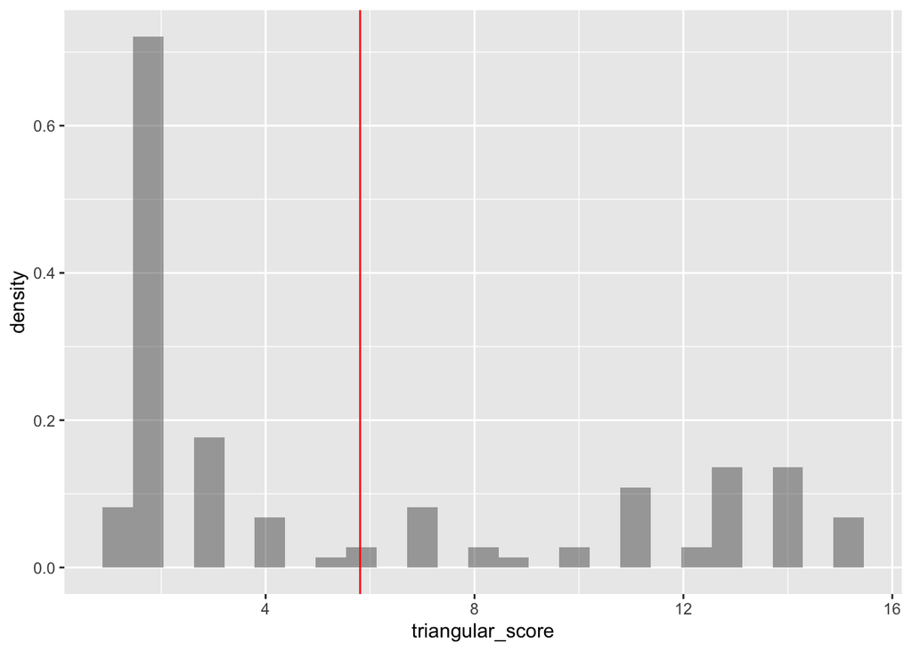

```r
#VISUALIZE distribution of response accuracy
gf_dhistogram(~triangular_score, data = df_subjects) %>%
  gf_vline(xintercept = score.stats$mean, color = "red")
```

Accuracy scores (n = 126) range from 1 to 15 with a mean score of (M = 5.81, SD = 4.89).

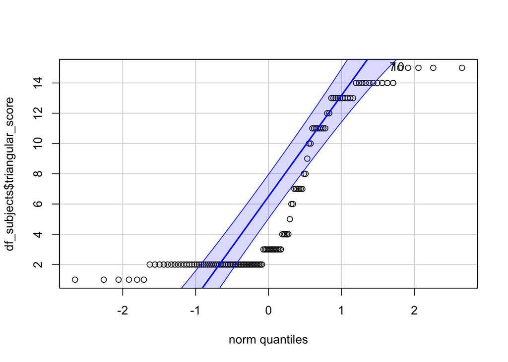

```
## [1]  7 10
```

```r
qqPlot(df_subjects$triangular_score)
```

## Response Latency

### TODO: Investigate response times

TODO: Investigate super high and super low response times..

```r
#DESCRIBE distribution of triangular-correct scores
time.stats <- favstats(df_subjects$tt_min)
time.stats
```

```
##     min       Q1   median       Q3      max    mean       sd   n missing
##  3.7708 7.283617 8.804333 10.71089 19.98955 9.25302 2.902315 126       0
```

```r
stat.desc(df_subjects$tt_min)
```

```
##      nbr.val     nbr.null       nbr.na          min          max        range
##  126.0000000    0.0000000    0.0000000    3.7708000   19.9895500   16.2187500
##          sum       median         mean      SE.mean CI.mean.0.95          var
## 1165.8804833    8.8043333    9.2530197    0.2585588    0.5117200    8.4234343
##      std.dev     coef.var
##    2.9023153    0.3136614
```

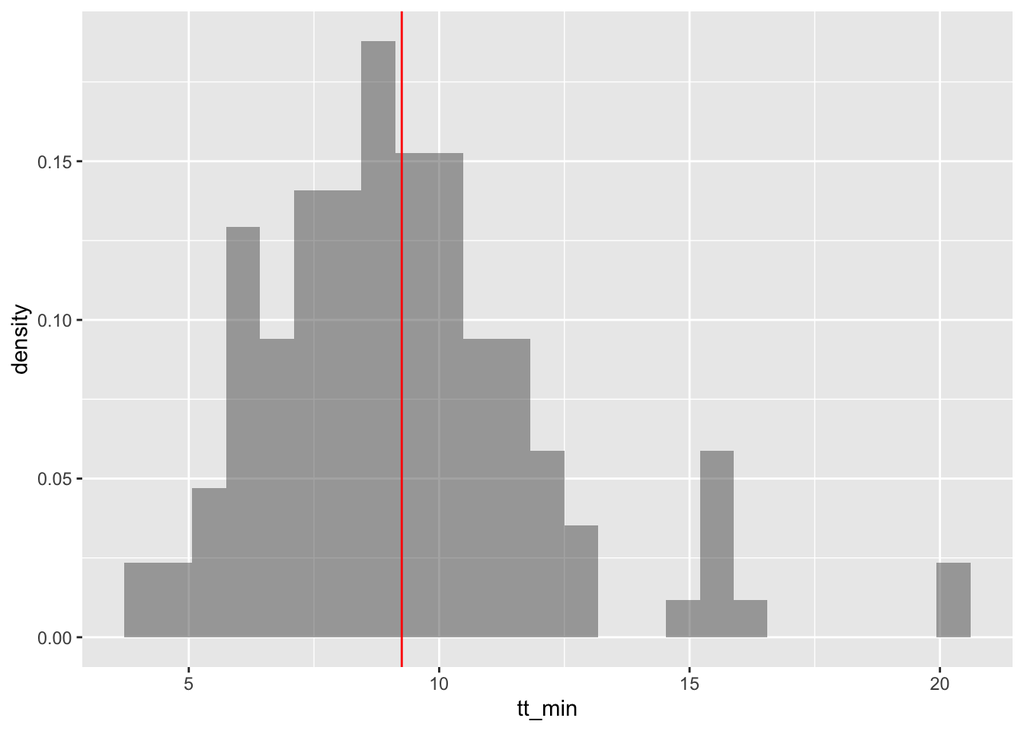

```r
#VISUALIZE distribution of response accuracy
gf_dhistogram(~tt_min, data = df_subjects) %>%
  gf_vline(xintercept = time.stats$mean, color = "red")
```

Response latency (for test blocks) range from 3.77 minutes to 19.99 minutes with a mean time of (M = 9.25, SD = 2.9).

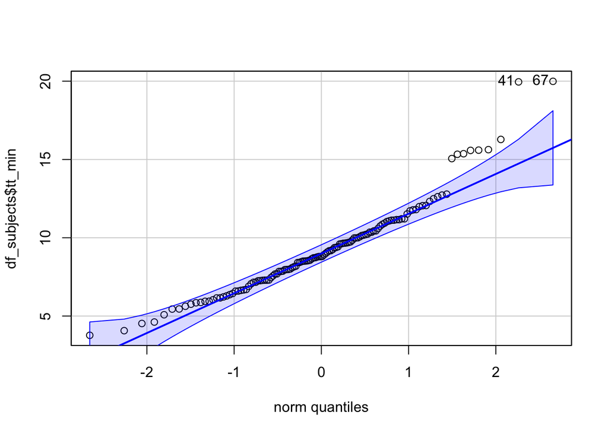

```
## [1] 67 41
```

```r
qqPlot(df_subjects$tt_min)
```

# HYPOTHESIS TESTING

## Response Accuracy by Condition

The experimental hypothesis (H1) is that structuring the data to pose an impasse (condition 121) will produce significantly better performance than non-impasse (condition 111). The null hypothesis (H0) is that there will be no difference in performance between conditions. A linear model predicting triangular_score from condition indicates a statistically significant difference between conditions, explaning 7% of the model variance.

### [EXPLORE]

```r
#DESCRIBE scores by condition
score.cond.stats <- favstats(triangular_score ~ condition, data = df_subjects)
score.cond.stats
```

```
##   condition min Q1 median    Q3 max     mean       sd  n missing
## 1       111   1  2    2.0  3.75  15 4.500000 4.643875 62       0
## 2       121   1  2    6.5 12.00  15 7.078125 4.828174 64       0
```

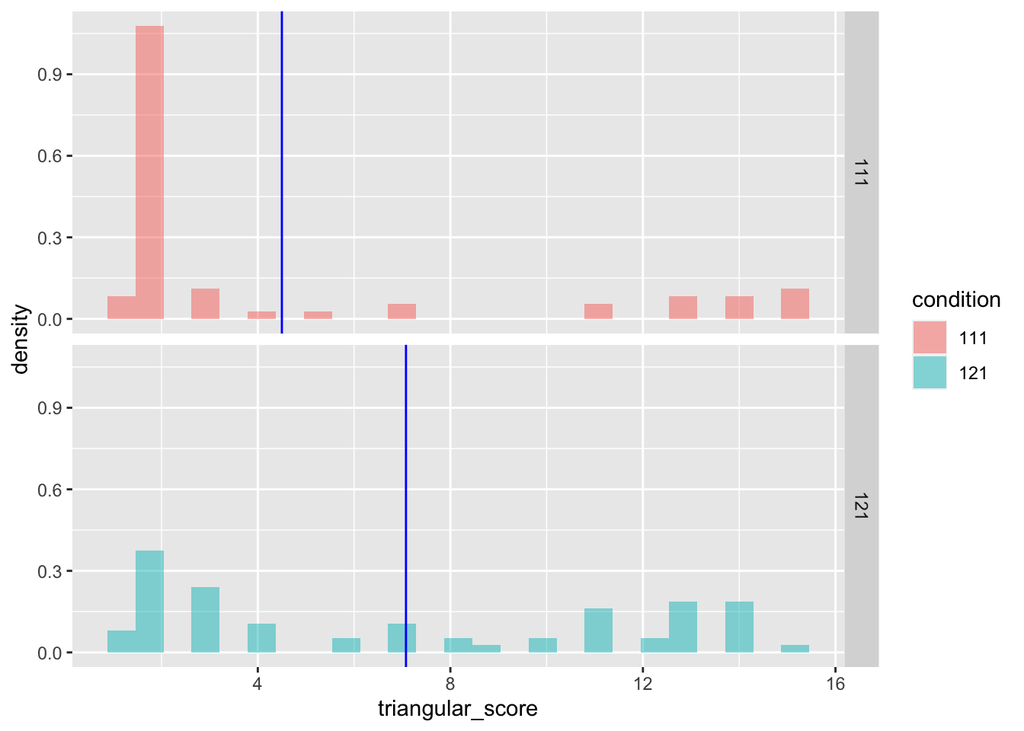

```r
#VISUALIZE scores by condition
gf_dhistogram( ~triangular_score, fill= ~condition, data = df_subjects) %>%
  gf_facet_grid(condition~.) %>%
  gf_vline(xintercept = ~mean, data = score.cond.stats, color = "blue")
```

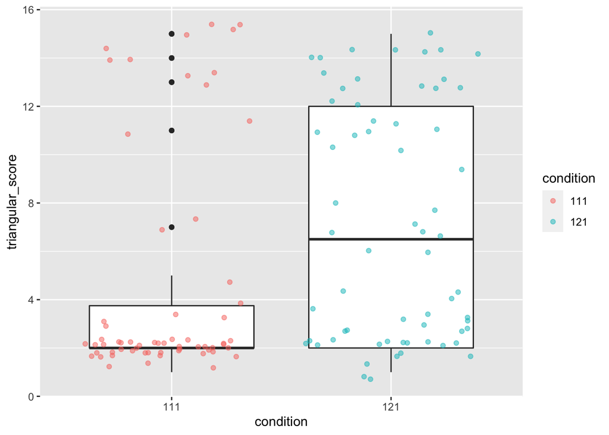

```r
#VISUALIZE scores by condition
gf_boxplot(triangular_score ~ condition, data=df_subjects) %>%
  gf_jitter(color=~condition, alpha=0.5)
```

Accuracy scores (n = 126) range from 1 to 15 with a mean score of (M = 5.81, SD = 4.89). On average, participants in the impasse group had higher scores (M = 7.08 SD = 4.83) than those in #the non-impasse control group (M = 4.5, SD = 4.64)**

### [MODEL]

```r
#MODEL triangular score by condition with a linear model
m1 = lm(triangular_score ~ condition, data = df_subjects)
m1
```

```
##
## Call:
## lm(formula = triangular_score ~ condition, data = df_subjects)
##
## Coefficients:
##  (Intercept)  condition121
##        4.500         2.578
```

```r
#the first co-efficient represents the model estimate for the first group, the second, the difference for the second group

# partition variance with anova
# anova(m1)
# supernova(m1) #runs but doesn't knit?

#calculate effect size
eta_squared(m1, partial = FALSE)
```

```
## # Effect Size for ANOVA (Type I)
##
## Parameter | Eta2 |       95% CI
## -------------------------------
## condition | 0.07 | [0.01, 1.00]
##
## - One-sided CIs: upper bound fixed at (1).
```

A linear model predicting triangular score accuracy by condition explains approximately 7% of the variance in triangular score F(1,124) = 9.32, p < 0.05)

# POST-HOC EXPLORATION

## 1. Power Analysis

What is the appropriate sample size to detect a moderate-sized effect (f = 0.25) at a 0.05 alpha level?

```r
#K = 2 groups, f = 0.25 is moderate effect size
pwr.anova.test(k=2,f=0.25 ,sig.level=.05, power=.8)
```

```
##
##      Balanced one-way analysis of variance power calculation
##
##               k = 2
##               n = 63.76561
##               f = 0.25
##       sig.level = 0.05
##           power = 0.8
##
## NOTE: n is number in each group
```

## 2. TERM-LEVEL analysis

Data from the first term only (Fall 2017) were analyzed and presented as a paper at CogSci 2019, in support of the experimental hypothesis (H1: impasse is an effective scaffold). Combined across terms, the prior analyses ALSO support the experimental hypothesis. Do the spring-only data also support the H1 hypothesis?

```r
#simple linear model predicting triangle score from condition for spring data only
mspring = lm(triangular_score ~ condition, data = df_subjects %>% filter(term=='spring18'))

#partition variance
anova(mspring)# supernova(m2)
```

```
## Analysis of Variance Table
##
## Response: triangular_score
##           Df Sum Sq Mean Sq F value Pr(>F)
## condition  1   55.7  55.704  2.3986 0.1259
## Residuals 70 1625.6  23.223
```

```r
confint(mspring)
```

```
##                   2.5 %   97.5 %
## (Intercept)   3.3182580 6.567456
## condition121 -0.5064242 4.026115
```

## 3. Combining Fall and Spring

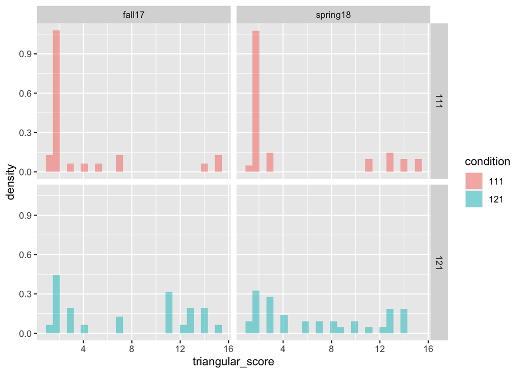

```r
#VISUALIZE scores by condition
gf_dhistogram( ~triangular_score, fill= ~condition, data = df_subjects) %>%
  gf_facet_grid(condition~term)
```

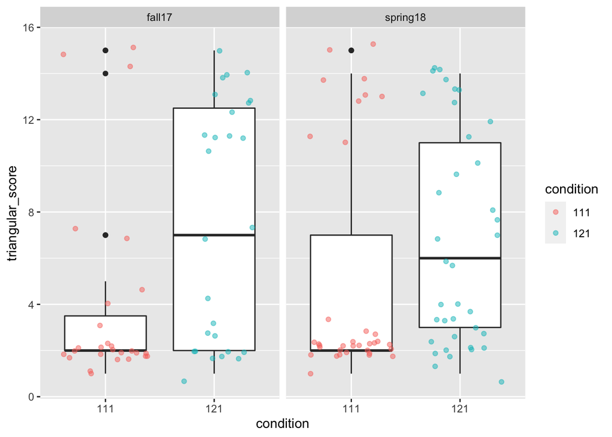

```r
#
# #VISUALIZE scores by condition
gf_boxplot(triangular_score ~ condition, data=df_subjects) %>%
  gf_facet_grid(~term) %>%
  gf_jitter(color=~condition, alpha=0.5)
```

By visual inspection, the distribution of accuracy scores across condition appear similiar across terms.

**It is therefore reasonable to conclude that data collected in Spring 2018 can be combined with Fall 2017.**